# Beetle Classification Performance Analysis (Cicindela + Platydracus)

# Deep Learning Model Performance for Beetle Taxonomy

This notebook analyzes classification performance of a multi-label deep learning model for identifying tiger beetle (*Cicindela*) and rove beetle (*Platydracus*) specimens. A single model is trained on the union of both genera; performance is examined per-genus across the three-level taxonomic hierarchy (genus / species / subspecies).

**Author**: B. de Medeiros, 2025

## Setup and Data Processing

```r
set.seed(1324)
library(tidyverse)
library(ggthemes)
library(cowplot)
```

The exported CSV (`test_results_<arch>.csv`) carries a `genus` column and a `taxonomic_level` column computed by the notebook. We recompute `taxonomic_level` here defensively (in case the CSV is older), using the label-format rule: capitalized → genus, `<genus>group_<group>` → species_group, exactly one `_` → species, two or more `_` → subspecies.

```r
performance_data <- read_csv("test_results_eva02_large_patch14_448.mim_m38m_ft_in22k_in1k.csv") %>%
  mutate(
    across(starts_with('micro'), ~ .x / 100),
    taxonomic_level = case_when(
      str_detect(Term, "^[A-Z]") ~ "genus",
      str_detect(Term, "^[a-z]+group_") ~ "species_group",
      str_count(Term, "_") == 1 ~ "species",
      TRUE ~ "subspecies"
    ),
    taxonomic_level = factor(taxonomic_level, levels = c("genus", "species_group", "species", "subspecies")),
    f1 = true_positives / (true_positives + (false_positives + false_negatives) / 2)
  ) %>%
  rename(
    taxon = Term,
    precision = micro_precision,
    recall = micro_recall,
    training_specimens = N_train,
    test_specimens = N
  )

glimpse(performance_data)
```

```
Rows: 273
Columns: 12
$ taxon              <chr> "Cicindela", "Platydracus", "cicindela_punctulata", "plat…
$ genus              <chr> "Cicindela", "Platydracus", "Cicindela", "Platydracus", "…
$ taxonomic_level    <fct> genus, genus, species, species_group, species, species, s…
$ training_specimens <dbl> 4883, 1596, 500, 361, 267, 276, 191, 200, 188, 217, 176, …
$ test_specimens     <dbl> 829, 230, 74, 51, 44, 42, 31, 30, 30, 30, 29, 22, 14, 14,…
$ precision          <dbl> 1, 1, 1, 1, 1, 1, 1, 1, 1, 1, 1, 1, 1, 1, 1, 1, 1, 1, 1, …
$ recall             <dbl> 1.0000000, 1.0000000, 1.0000000, 0.9411765, 1.0000000, 1.…
$ true_positives     <dbl> 829, 230, 74, 48, 44, 42, 30, 26, 30, 30, 29, 19, 14, 14,…
$ false_positives    <dbl> 0, 0, 0, 0, 0, 0, 0, 0, 0, 0, 0, 0, 0, 0, 0, 0, 0, 0, 0, …
$ false_negatives    <dbl> 0, 0, 0, 3, 0, 0, 1, 4, 0, 0, 0, 3, 0, 0, 0, 0, 0, 0, 0, …
$ confused_with      <chr> "cicindela_hirticollis_hirticollis (5), cicindela_repanda…
$ f1                 <dbl> 1.0000000, 1.0000000, 1.0000000, 0.9696970, 1.0000000, 1.…
```

We also pull in the Platydracus species-group mapping (`images/Platydracus/species_groups.csv`) so each species/subspecies row can be tagged with its group. Keys are built the same way as in the training notebook: `platydracus_<species>[_<subsp>]`.

```r
species_groups_raw <- read_csv("./species_groups.csv", show_col_types = FALSE)

species_group_map <- species_groups_raw %>%
  mutate(
    parts = str_split(str_trim(full_taxonomy), "\\s+"),
    genus_part = map_chr(parts, 1),
    rest = map_chr(parts, ~ paste(.x[-1], collapse = "_"))
  ) %>%
  filter(genus_part == "Platydracus", rest != "") %>%
  transmute(
    taxon = paste0("platydracus_", rest),
    species_group = str_trim(species_group)
  )

# Propagate species-level group to subspecies rows that aren't listed explicitly.
species_level_map <- species_group_map %>%
  filter(str_count(taxon, "_") == 1) %>%
  rename(species_taxon = taxon, species_group_from_species = species_group)

performance_data <- performance_data %>%
  mutate(
    species_taxon = if_else(
      genus == "Platydracus" & taxonomic_level %in% c("species", "subspecies"),
      str_extract(taxon, "^platydracus_[^_]+"),
      NA_character_
    )
  ) %>%
  left_join(species_group_map, by = "taxon") %>%
  left_join(species_level_map, by = "species_taxon") %>%
  mutate(
    species_group = coalesce(species_group, species_group_from_species)
  ) %>%
  select(-species_taxon, -species_group_from_species)
```

## Per-Genus, Per-Level Summary Statistics

```r
calculate_averages <- function(data, ...) {
  data %>%
    group_by(...) %>%
    summarise(
      precision_equal = mean(precision, na.rm = TRUE),
      recall_equal = mean(recall, na.rm = TRUE),
      precision_weighted = weighted.mean(precision, training_specimens, na.rm = TRUE),
      recall_weighted = weighted.mean(recall, training_specimens, na.rm = TRUE),
      n_terms = n(),
      .groups = 'drop'
    )
}
```

```r
summary_stats <- calculate_averages(performance_data, genus, taxonomic_level)

plot_averages <- summary_stats %>%
  select(-n_terms) %>%
  pivot_longer(cols = c(-genus, -taxonomic_level), names_to = 'metric') %>%
  mutate(
    weighted = str_detect(metric, '_weighted'),
    metric_clean = str_replace(metric, '^(.+?)_(equal|weighted)$', '\\1')
  ) %>%
  select(-metric) %>%
  pivot_wider(names_from = metric_clean, values_from = value) %>%
  mutate(
    weighting_type = if_else(weighted, "Weighted by specimens", "Equal taxa")
  )

print("Summary Statistics by Genus and Taxonomic Level:")
```

```
[1] "Summary Statistics by Genus and Taxonomic Level:"
```

```r
summary_stats
```

| genus | taxonomic_level | precision_equal | recall_equal | precision_weighted | recall_weighted | n_terms |
| --- | --- | --- | --- | --- | --- | --- |
| Cicindela | genus | 1.0000000 | 1.0000000 | 1.0000000 | 1.0000000 | 1 |
| Cicindela | species | 0.9689940 | 0.7710589 | 0.9719198 | 0.9577616 | 115 |
| Cicindela | subspecies | 0.9009648 | 0.6227622 | 0.8847338 | 0.8574760 | 80 |
| Platydracus | genus | 1.0000000 | 1.0000000 | 1.0000000 | 1.0000000 | 1 |
| Platydracus | species_group | 0.9925716 | 0.8841912 | 0.9870748 | 0.9644516 | 14 |
| Platydracus | species | 0.9468107 | 0.7862591 | 0.9340357 | 0.8895693 | 59 |
| Platydracus | subspecies | 1.0000000 | 0.8055556 | 1.0000000 | 0.8979358 | 3 |

## Precision-Recall Visualization (faceted by genus)

Genus-level classification is perfect for both *Cicindela* and *Platydracus* (precision = recall = 100%), so we omit it from the figures below and note it in text.

```r
plot_data <- performance_data %>%
  filter(taxonomic_level != "genus") %>%
  mutate(taxonomic_level = droplevels(taxonomic_level)) %>%
  arrange(desc(training_specimens))

plot_averages_sub <- plot_averages %>%
  filter(taxonomic_level != "genus") %>%
  mutate(taxonomic_level = droplevels(taxonomic_level))
```

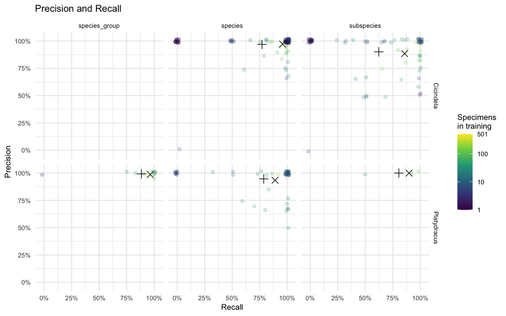

```r
precision_recall_plot <- ggplot() +
  geom_jitter(
    data = plot_data,
    aes(y = precision, x = recall, color = training_specimens),
    width = 0.02,
    height = 0.02,
    alpha = 0.2
  ) +
  geom_point(
    data = plot_averages_sub,
    aes(y = precision, x = recall, shape = weighted),
    size = 3
  ) +
  scale_shape_manual(
    values = c(3, 4),
    name = 'Averaging',
    labels = c("taxa", 'specimens'),
    guide = 'none'
  ) +
  scale_color_viridis_c(
    trans = 'log10',
    name = "Specimens\nin training",
    breaks = c(1, 10, 100, max(plot_data$training_specimens))
  ) +
  scale_x_continuous(labels = scales::percent, breaks = seq(0,1,by=.25), limits=c(-0.03,1.03)) +
  scale_y_continuous(labels = scales::percent, breaks = seq(0,1,by=.25), limits=c(-0.03,1.03)) +
  ggtitle("Precision and Recall") +
  xlab("Recall") +
  ylab("Precision") +
  facet_grid(genus ~ taxonomic_level) +
  theme_minimal() +
  theme(text = element_text(size=9))

print(precision_recall_plot)
```

## Performance vs Training Data Size

```r
training_size_data <- performance_data %>%
  arrange(desc(training_specimens)) %>%
  pivot_longer(
    cols = c("precision", "recall"),
    names_to = "metric",
    values_to = "value"
  )
```

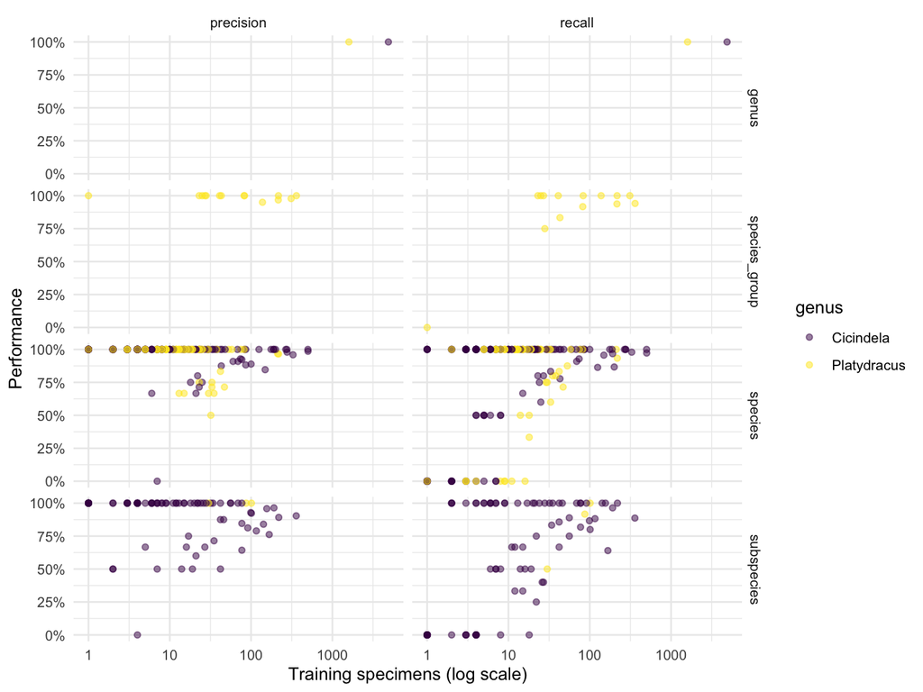

```r
training_size_plot <- ggplot(training_size_data) +
  geom_jitter(
    aes(x = training_specimens, y = value, color = genus),
    width = 0,#0.03,
    height = 0,#0.03,
    alpha = 0.5
  ) +
  scale_x_log10() +
  scale_y_continuous(labels = scales::percent) +
  xlab("Training specimens (log scale)") +
  ylab("Performance") +
  scale_colour_viridis_d() +
  facet_grid(taxonomic_level ~ metric) +
  theme_minimal()

print(training_size_plot)
```

## Key Findings Summary

```r
cat("Dataset Overview:\n")
```

```
Dataset Overview:
```

```r
cat(sprintf("- Total taxa analyzed: %d\n", nrow(performance_data)))
```

```
- Total taxa analyzed: 273
```

```r
for (g in sort(unique(performance_data$genus))) {
  gdata <- performance_data %>% filter(genus == g)
  cat(sprintf("\n%s (n_terms = %d):\n", g, nrow(gdata)))
  for (lvl in c("genus", "species", "subspecies")) {
    sub <- gdata %>% filter(taxonomic_level == lvl)
    if (nrow(sub) == 0) next
    row <- summary_stats %>% filter(genus == g, taxonomic_level == lvl)
    cat(sprintf("  %-10s  n=%3d  precision (equal)=%.1f%%  recall (equal)=%.1f%%  precision (wt)=%.1f%%  recall (wt)=%.1f%%\n",
                lvl, nrow(sub),
                100 * row$precision_equal, 100 * row$recall_equal,
                100 * row$precision_weighted, 100 * row$recall_weighted))
  }
}
```

```
Cicindela (n_terms = 196):
  genus       n=  1  precision (equal)=100.0%  recall (equal)=100.0%  precision (wt)=100.0%  recall (wt)=100.0%
  species     n=115  precision (equal)=96.9%  recall (equal)=77.1%  precision (wt)=97.2%  recall (wt)=95.8%
  subspecies  n= 80  precision (equal)=90.1%  recall (equal)=62.3%  precision (wt)=88.5%  recall (wt)=85.7%

Platydracus (n_terms = 77):
  genus       n=  1  precision (equal)=100.0%  recall (equal)=100.0%  precision (wt)=100.0%  recall (wt)=100.0%
  species     n= 59  precision (equal)=94.7%  recall (equal)=78.6%  precision (wt)=93.4%  recall (wt)=89.0%
  subspecies  n=  3  precision (equal)=100.0%  recall (equal)=80.6%  precision (wt)=100.0%  recall (wt)=89.8%
```

## Training Sample Distribution

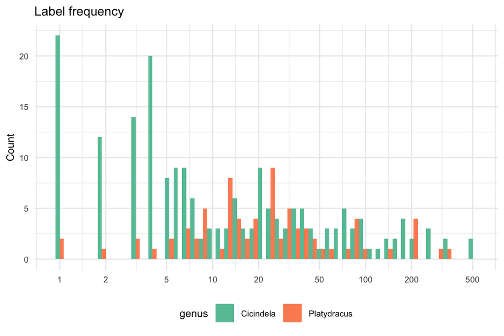

```r
dist_plot <- ggplot(plot_data) +
  geom_histogram(
    aes(x = training_specimens, fill = genus),
    bins = 50,
    position = "dodge"
  ) +
  scale_fill_brewer(palette = "Set2") +
  scale_x_log10(breaks=c(1,2,5,10,20,50,100,200,500)) +
  ggtitle("Label frequency") +
  xlab(NULL) +
  ylab("Count") +
  theme_minimal() +
  theme(text = element_text(size=9), legend.position = "bottom")

dist_plot
```

## F1 Score vs Training Sample Size

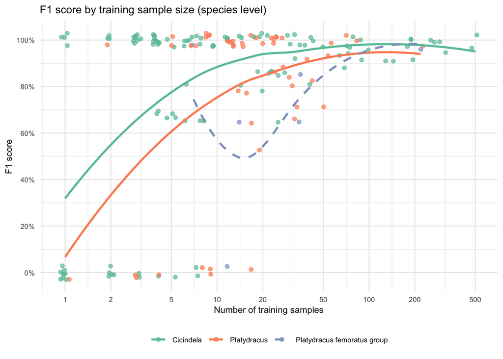

```r
curve_levels <- c("Cicindela", "Platydracus", "Platydracus femoratus group")

f1_data <- plot_data %>%
  filter(taxonomic_level == "species") %>%
  mutate(
    point_group = case_when(
      genus == "Cicindela" ~ "Cicindela",
      genus == "Platydracus" & species_group == "femoratus" ~ "Platydracus femoratus group",
      genus == "Platydracus" ~ "Platydracus"
    ),
    point_group = factor(point_group, levels = curve_levels)
  )

curve_data <- bind_rows(
  f1_data %>% filter(genus == "Cicindela") %>% mutate(curve_group = "Cicindela"),
  f1_data %>% filter(genus == "Platydracus") %>% mutate(curve_group = "Platydracus"),
  f1_data %>%
    filter(genus == "Platydracus", species_group == "femoratus") %>%
    mutate(curve_group = "Platydracus femoratus group")
) %>%
  mutate(curve_group = factor(curve_group, levels = curve_levels))

set2 <- RColorBrewer::brewer.pal(3, "Set2")
curve_colors <- c(
  "Cicindela"                    = set2[1],
  "Platydracus"                  = set2[2],
  "Platydracus femoratus group"  = set2[3]
)
curve_linetypes <- c(
  "Cicindela"                    = "solid",
  "Platydracus"                  = "solid",
  "Platydracus femoratus group"  = "dashed"
)

f1_plot <- ggplot() +
  geom_jitter(
    data = f1_data,
    aes(x = training_specimens, y = f1, color = point_group),
    width = 0.03,
    height = 0.03,
    alpha = 0.7,
    size = 1.6
  ) +
  geom_smooth(
    data = curve_data,
    aes(x = training_specimens, y = f1,
        color = curve_group, linetype = curve_group),
    method = "loess",
    span = 1.2,
    se = FALSE
  ) +
  scale_x_log10(breaks = c(1, 2, 5, 10, 20, 50, 100, 200, 500)) +
  scale_y_continuous(
    labels = scales::percent,
    breaks = seq(0, 1.00, by = 0.20)
  ) +
  scale_color_manual(
    values = curve_colors,
    breaks = c("Cicindela", "Platydracus", "Platydracus femoratus group"),
    name = NULL
  ) +
  scale_linetype_manual(
    values = curve_linetypes,
    breaks = c("Cicindela", "Platydracus", "Platydracus femoratus group"),
    name = NULL
  ) +
  ggtitle("F1 score by training sample size (species level)") +
  xlab("Number of training samples") +
  ylab("F1 score") +
  theme_minimal() +
  theme(text = element_text(size = 9), legend.position = "bottom")

f1_plot
```

```r
f1_data %>%
  filter(genus == "Platydracus", !is.na(species_group)) %>%
  group_by(species_group) %>%
  summarise(
    n_taxa = n(),
    median_f1 = median(f1, na.rm = TRUE),
    mean_f1 = mean(f1, na.rm = TRUE),
    median_train = median(training_specimens),
    .groups = "drop"
  ) %>%
  arrange(median_f1)
```

| species_group | n_taxa | median_f1 | mean_f1 | median_train |
| --- | --- | --- | --- | --- |
| cinnamopterus | 3 | 0.0000000 | 0.3333333 | 9.0 |
| immaculatus | 1 | 0.0000000 | 0.0000000 | 1.0 |
| tomentosus | 7 | 0.6666667 | 0.4510204 | 16.0 |
| femoratus | 6 | 0.7500000 | 0.6917122 | 23.5 |
| cyanomelas | 7 | 0.8888889 | 0.8771387 | 30.0 |
| fossator | 4 | 0.9000000 | 0.7000000 | 12.0 |
| centralis | 2 | 0.9285714 | 0.9285714 | 20.5 |
| apicipennis | 2 | 1.0000000 | 1.0000000 | 14.0 |
| buquetii | 8 | 1.0000000 | 0.9642857 | 18.0 |
| caliginosus | 5 | 1.0000000 | 0.7866667 | 9.0 |

[output cut: 4 more lines]

## Combined Performance Visualization

```r
legend_AB <- get_legend(
  f1_plot + theme(
    legend.position = 'bottom',
    legend.box = 'vertical',
    legend.box.spacing = unit(0, 'pt'),
    legend.spacing.y = unit(-4, 'pt'),
    legend.margin = margin(0, 0, 0, 0)
  )
)
legend_C  <- get_legend(
  precision_recall_plot +
    theme(legend.position = 'bottom', legend.box = 'horizontal') +
    guides(color = guide_colorbar(barwidth = 8, barheight = 0.6))
)
```

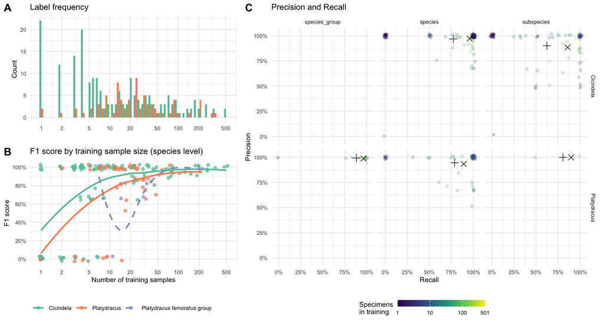

```r
p_AB <- cowplot::plot_grid(
  dist_plot + theme(legend.position = 'none'),
  f1_plot + theme(legend.position = 'none'),
  ncol = 1,
  labels = "AUTO",
  align = 'hv',
  axis = 'lrtb'
)

top_row <- cowplot::plot_grid(
  p_AB,
  precision_recall_plot + theme(legend.position = 'none'),
  rel_widths = c(0.8, 1.2),
  nrow = 1,
  labels = c("", "C")
)

legend_row <- cowplot::plot_grid(
  legend_AB,
  legend_C,
  rel_widths = c(0.8, 1.2),
  nrow = 1
)

p <- cowplot::plot_grid(
  top_row,
  legend_row,
  ncol = 1,
  rel_heights = c(1, 0.14)
)

p
```

## Export Publication Figures

```r
ggsave(
  filename = 'taxonomy_metrics.pdf',
  plot = p,
  device = 'pdf',
  width = 11,
  height = 5,
  units = 'in',
  useDingbats = FALSE
)

ggsave(
  filename = 'taxonomy_metrics.png',
  plot = p,
  device = 'png',
  width = 11,
  height = 5,
  units = 'in',
  dpi = 300
)
```

## Individual Taxon Inspection

```r
performance_data %>%
  filter(taxon %in% c("cicindela_sylvicola", "Cicindela", "Platydracus","platydracusgroup_femoratus"))
```

| taxon | genus | taxonomic_level | training_specimens | test_specimens | precision | recall | true_positives | false_positives | false_negatives | confused_with | f1 | species_group |
| --- | --- | --- | --- | --- | --- | --- | --- | --- | --- | --- | --- | --- |
| Cicindela | Cicindela | genus | 4883 | 829 | 1.0000000 | 1.0 | 829 | 0 | 0 | cicindela_hirticollis_hirticollis (5), cicindela_repanda_repanda (5), cicindela_punctulata_punctulata (5), cicindela_oregona_oregona (4), cicindela_longilabris_perviridis (4), cicindela_tranquebarica_… | 1.0000000 | NA |
| Platydracus | Platydracus | genus | 1596 | 230 | 1.0000000 | 1.0 | 230 | 0 | 0 | platydracus_discors (4), platydracus_arinemexus (2), platydracus_optatus (2), platydracus_phoenicurus (2), platydracus_championi (2), platydracus_fervidus (1), platydracusgroup_buquetii (1), platydrac… | 1.0000000 | NA |
| platydracusgroup_femoratus | Platydracus | species_group | 311 | 45 | 0.9782609 | 1.0 | 45 | 1 | 0 | platydracus_championi (2), platydracus_ignotus (1) | 0.9890110 | NA |
| cicindela_sylvicola | Cicindela | species | 25 | 5 | 0.7500000 | 0.6 | 3 | 1 | 2 | cicindela_depressula (1), cicindela_hybrida (1) | 0.6666667 | NA |